# Prospective causal-gap sensitivity analysis across trial designs

R package, interactive lessons and replication code

Se Yoon Lee

**Estimate in R**Install the package and fit AIPW-U.**Compare the four models**Read the equations and inspect one record.**Reproduce the paper**Generate the numbered tables and figures.

A trial team has 300 external controls and plans to treat 120 children. How many children should it still randomize to concurrent control? The trial design lab lets you compare enrollment plans before fitting a model. The EIF lab shows how a change in the control distribution affects the borrowing contrast. For a worked application after data collection, see the glucose monitoring analysis.

Explore the four model spaces and their efficiency bounds to see how a common control mean and the planned enrollment affect precision.

Follow the interactive trial timeline from protocol design and scientific advice through enrollment and analysis.

Download replication project (.zip)Download numerical tables (.zip)Guide source (.Rmd)

# Reproduce the paper’s tables

Extract the replication code, open `HCT.Rproj` in RStudio, and use the R console. The package need not be installed. These commands use base R and bundled aggregate summaries to write CSVs under `results/tables/`.

```r
source("analysis/reproduce.R")
reproduce("tables")
```

| Paper display | Calculation or source | Output in `results/tables/` |
| --- | --- | --- |
| Main Table 2 | Oracle and fitted coverage, bias, mean squared error, and interval width at both trial sizes | `table-2.csv` |
| Main Table 3 | Gaussian planning calculations for three schizophrenia trial scenarios | `table-3a.csv`, `table-3b.csv` |
| Supplementary Tables S4 and S7–S13 | Analytical examples, additional simulations, planning calculations, and clinical diagnostics | `table-s4.csv` and files beginning `table-s7` through `table-s13` |
| Supplementary Table S14 | Six-month HbA1c estimates and bootstrap intervals from the saved clinical summaries | `table-s14.csv` |

Main Table 1 gives the terms of the hybrid trial’s efficient influence function. Tables S1–S3 define notation, observed groups, and nuisance quantities. Tables S5 and S6 identify the analysis settings, simulation scenarios, and corresponding results. The exhibit map (`analysis/paper-map.csv`) identifies the source for each figure and table. The simulation and clinical sections below explain how to refit the analyses that produced the saved summaries.

# Reproduce the figures

With Cairo graphics available in R (`capabilities("cairo")`), install the two packages with `install.packages(c("jsonlite", "digest"))` and run `reproduce("figures")` in the same session. This writes `Figure-01.pdf` through `Figure-11.pdf`, `Figure-S01.pdf` through `Figure-S11.pdf`, and `figure-index.csv` under `results/figures/`. Figures 1, 5, S1, and S4 use the supplied vector artwork. Sampling plots use supplied synthetic draws, simulation plots use saved summaries, and the CGM figures use aggregate data. Figures S9–S11 show cohort selection, HbA1c outcomes, and baseline covariate balance. The [exhibit index](https://github.com/yain22/Unified_Semiparametric_HCT/blob/main/analysis/paper-map.csv) lists the source for each display. Neither this command nor the table command refits a simulation or needs participant records.

# A design decision before enrollment

In Scenario I, all three designs enroll 120 treated children. The hybrid trial (HCT) recruits 60 concurrent controls and borrows 300 external controls. The externally controlled single-arm trial (ECT) uses the same external cohort. The randomized controlled trial (RCT) recruits 120 concurrent controls. Improvement in the negative symptom score is measured in points, with larger values favoring treatment. The planned effect is two points.

## Power when control outcomes agree

The planning model assumes a marginal outcome standard deviation of 7.5 and a common prognostic function explaining 25% of outcome variance. The residual variance is therefore $v=7.5^2(1-0.25)$. With equal residual variances, the HCT assigns $60/(60+300)=1/6$ of its control mean to concurrent controls. The calculation uses fixed weights and independent arm means. For RCT ANCOVA, it uses the known prognostic function as a planning approximation to fitted regression adjustment.

```r
treated <- 120
rct_control <- 120
hybrid_control <- 60
external_control <- 300
residual_variance <- 7.5^2 * (1 - 0.25)
cutoff <- qnorm(0.975)
trial_effect <- 2

se <- sqrt(residual_variance * c(
  HCT = 1 / treated + 1 / (hybrid_control + external_control),
  ECT = 1 / treated + 1 / external_control,
  RCT = 1 / treated + 1 / rct_control
))
power <- pnorm(trial_effect / se - cutoff)

knitr::kable(
  data.frame(Design = c("HCT", "ECT", "RCT (ANCOVA)"),
             "New trial enrollment" = c(180, 120, 240),
             "Standard error" = unname(se),
             "Power" = unname(power), check.names = FALSE),
  digits = c(0, 0, 3, 3), align = c("l", "r", "r", "r"))
```

| Design | New trial enrollment | Standard error | Power |
| --- | --- | --- | --- |
| HCT | 180 | 0.685 | 0.832 |
| ECT | 120 | 0.702 | 0.813 |
| RCT (ANCOVA) | 240 | 0.839 | 0.665 |

At the two-point effect, both borrowing designs exceed the planned 80% power; the candidate randomized ANCOVA design has approximately 67% power. Those values assume equal internal and external mean control outcomes at the same baseline covariates.

## What if the external controls improve less?

Let $\delta$ be the internal mean control outcome minus the external mean for comparable patients. Under a constant discrepancy, the borrowing contrast exceeds the trial effect by $\xi=(1-\lambda)\delta$, where $\lambda$ is the internal share. Here the HCT gap is $5\delta/6$, the ECT gap is $\delta$, and the RCT gap is zero. The graph uses the **same external discrepancy** for both borrowing designs. When the true trial effect is zero, the probability of declaring benefit is $\Phi(\xi/s-z_{0.975})$, where $s$ is the planning standard error.

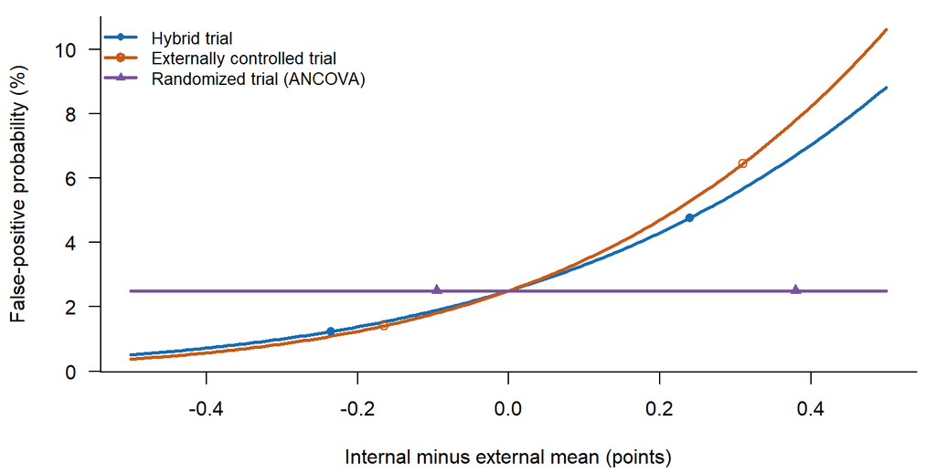

```r
external_share <- c(HCT = external_control / (hybrid_control + external_control),
                    ECT = 1, RCT = 0)
delta <- seq(-0.5, 0.5, length.out = 201)
false_positive <- sapply(names(se), function(design) {
  pnorm(external_share[design] * delta / se[design] - cutoff)
})

old_par <- par(mar = c(4.2, 4.2, 0.7, 0.8))
colors <- c("#176CB0", "#C75A18", "#7952A0")
shapes <- c(16, 1, 17)
matplot(delta, 100 * false_positive, type = "l", lty = 1,
        col = colors, lwd = 2.6, xlab = "Internal minus external mean (points)",
        ylab = "False-positive probability (%)", las = 1, bty = "l")
for (j in seq_along(shapes)) {
  at <- seq(40L + 14L * j, length(delta), by = 95L)
  points(delta[at], 100 * false_positive[at, j], pch = shapes[j], col = colors[j])
}
legend("topleft", legend = c("Hybrid trial", "Externally controlled trial",
       "Randomized trial (ANCOVA)"), col = colors, lty = 1, pch = shapes, lwd = 2.6,
       bty = "n", cex = 0.85)
par(old_par)
```

At an internal-minus-external difference of 0.5 points, the hybrid trial declares benefit under the null about 8.8% of the time, the externally controlled trial about 10.6%, and the randomized trial 2.5%. Retaining concurrent controls attenuates the displacement. The hybrid design still exceeds the nominal false-positive probability. To reproduce all three scenarios, including the separate analysis in which the designs have the same *gap*, run:

```bash
Rscript analysis/paper_analysis.R planning
```

# Refit the simulations

The simulations fit the hybrid AIPW-U estimator using separate internal and external control regressions, and compare it with ECT AIPW and randomized analyses. Unlike the calculation above, the fitted hybrid procedure estimates the borrowing share and includes its variation in the estimating equation.

Install the R dependencies once, then run four replications to check the code and generate new output. The paired oracle analysis reads the fitted baseline run with the same seed and number of replications.

```r
install.packages(c("data.table", "digest", "jsonlite"))
```

```bash
Rscript analysis/paper_analysis.R validate
Rscript analysis/paper_analysis.R baseline --reps 4 --output-dir results/smoke/baseline
Rscript analysis/paper_analysis.R oracle --reps 4 --baseline-dir results/smoke/baseline --output-dir results/smoke/oracle
Rscript analysis/paper_analysis.R extended --reps 4 --output-dir results/smoke/extended
```

For the paper’s Monte Carlo precision, use the 5,000-replication commands below. The baseline and extended runs accept a worker count. The scripts use the manuscript’s seeds by default.

```bash
Rscript analysis/paper_analysis.R baseline --reps 5000 --workers 4
Rscript analysis/paper_analysis.R oracle --reps 5000 --baseline-dir results/baseline
Rscript analysis/paper_analysis.R extended --reps 5000 --workers 4
Rscript analysis/paper_analysis.R quadratic --reps 5000
```

For the full sequence, including the quadratic comparator, calibration, one-sided operating characteristics, tables and figures from new runs, use `source("analysis/reproduce.R"); reproduce("refit", workers = 4)` in the project R console. For four paired repetitions, use `reproduce("smoke")`. That test does not reproduce the Monte Carlo precision of the paper. To plot already completed runs, use `Rscript analysis/simulations/plot_publication.R --help`.

# Examine the glucose monitoring analysis

The outcome is six-month change in HbA1c, measured in percentage points. Negative treatment contrasts favor continuous glucose monitoring. In this application the HCT uses all 442 retained trial profiles. The ECT uses 228 registry-eligible treated profiles as its standardization population. The HCT causal-gap estimate compares AIPW-U with the trial-only augmented estimate calculated from the **same fitted trial regressions**.

This code reads the distributed aggregate results. It reproduces the two treatment contrasts underlying the matched gap, and shows the interval calculated from 2,000 paired participant bootstrap refits. The pairing preserves the covariance between the two estimates.

```r
file <- "analysis/clinical/inputs/primary/full_results.csv"
cgm <- read.csv(file)
methods <- c("AIPW-U (est)", "trial_augmented", "matching_gap")
rows <- cgm[match(methods, cgm$method), ]
stopifnot(!anyNA(rows$estimate),
          abs(rows$estimate[1] - rows$estimate[2] - rows$estimate[3]) < 1e-10)

knitr::kable(
  data.frame(Contrast = c("HCT AIPW-U", "Matched trial-only estimate", "Causal-gap"),
             Estimate = rows$estimate, "Lower 95%" = rows$bootstrap_lower,
             "Upper 95%" = rows$bootstrap_upper, check.names = FALSE),
  digits = 3, align = c("l", "r", "r", "r"))
```

| Contrast | Estimate | Lower 95% | Upper 95% |
| --- | --- | --- | --- |
| HCT AIPW-U | -0.278 | -0.374 | -0.182 |
| Matched trial-only estimate | -0.228 | -0.330 | -0.126 |
| Causal-gap | -0.050 | -0.093 | -0.007 |

Borrowing shifts the estimated HbA1c contrast by approximately −0.050 percentage points relative to the matched trial score. To refit the estimators or recompute the bootstrap, obtain the JDRF trial and T1D Exchange registry archives separately from the Jaeb Center for Health Research under its access terms. Replace the two filenames below with your authorized local copies. The public bundle contains aggregate estimates and diagnostics; the underlying participant records are held by the distributor.

```bash
Rscript analysis/paper_analysis.R cgm --trial-zip trial.zip --registry-zip registry.zip --bootstrap-reps 2000
```

Cohort construction, eligibility windows, and the registry-use sensitivity analysis are documented in `analysis/clinical/README.md`.

# Render this manual

Run the following in R from the extracted replication folder, which contains `analysis/` and `docs/index.Rmd`:

```r
install.packages(c("rmarkdown", "knitr"))
rmarkdown::render("docs/index.Rmd", knit_root_dir = normalizePath("."))
```

Rendering requires Pandoc, which is included with RStudio. The worked planning example uses base R; the clinical example reads the supplied aggregate CSV. The HTML includes the executed results and the figure.